# Aufgabenblatt 02: Generalisierte lineare Modelle

Anatol

3/22/2022

# Aufgabe 1: Logit Modelle

```r
insur <- read.csv("insurance.csv")
head(insur)
```

| ins | retire | age | hstatusg | hhincome | educyear | married | hisp | personid | private | eprhi | white | female | excel | vegood | good | fair | poor | chronic | adl | seprhi | sretire | age2 | agefem | agechr | agewhi |
| --- | --- | --- | --- | --- | --- | --- | --- | --- | --- | --- | --- | --- | --- | --- | --- | --- | --- | --- | --- | --- | --- | --- | --- | --- | --- |
| 0 | 0 | 62 | 0 | 0 | 12 | 0 | 0 | 54963010 | 0 | 0 | 0 | 1 | 0 | 0 | 0 | 1 | 0 | 3 | 0 | 0 | 0 | 3844 | 62 | 186 | 0 |
| 0 | 0 | 59 | 0 | 0 | 12 | 0 | 0 | 21629010 | 0 | 0 | 1 | 1 | 0 | 0 | 0 | 1 | 0 | 1 | 3 | 0 | 0 | 3481 | 59 | 59 | 59 |
| 0 | 1 | 60 | 1 | 0 | 13 | 0 | 0 | 20421010 | 0 | 0 | 0 | 0 | 0 | 1 | 0 | 0 | 0 | 2 | 0 | 0 | 0 | 3600 | 0 | 120 | 0 |
| 0 | 0 | 62 | 0 | 0 | 10 | 0 | 0 | 38784010 | 0 | 0 | 1 | 1 | 0 | 0 | 0 | 1 | 0 | 4 | 3 | 0 | 0 | 3844 | 62 | 248 | 62 |
| 0 | 0 | 54 | 0 | 0 | 9 | 0 | 0 | 55630030 | 0 | 0 | 1 | 1 | 0 | 0 | 0 | 0 | 1 | 6 | 0 | 0 | 0 | 2916 | 54 | 324 | 54 |
| 0 | 1 | 62 | 1 | 0 | 12 | 1 | 0 | 15893020 | 0 | 0 | 1 | 1 | 0 | 1 | 0 | 0 | 0 | 0 | 0 | 0 | 1 | 3844 | 62 | 0 | 62 |

```r
str(insur)
```

```
## 'data.frame':    3206 obs. of  26 variables:
##  $ ins     : int  0 0 0 0 0 0 0 0 0 0 ...
##  $ retire  : int  0 0 1 0 0 1 0 0 0 0 ...
##  $ age     : int  62 59 60 62 54 62 59 59 65 58 ...
##  $ hstatusg: int  0 0 1 0 0 1 0 0 0 0 ...
##  $ hhincome: num  0 0 0 0 0 0 0 0 0 0.101 ...
##  $ educyear: int  12 12 13 10 9 12 5 11 14 12 ...
##  $ married : int  0 0 0 0 0 1 1 0 0 0 ...
##  $ hisp    : int  0 0 0 0 0 0 0 0 0 0 ...
##  $ personid: int  54963010 21629010 20421010 38784010 55630030 15893020 86263010 51270010 57341010 39703010 ...
##  $ private : int  0 0 0 0 0 0 0 0 0 0 ...
##  $ eprhi   : int  0 0 0 0 0 0 0 0 0 0 ...
##  $ white   : int  0 1 0 1 1 1 0 1 0 1 ...
##  $ female  : int  1 1 0 1 1 1 0 1 0 1 ...
##  $ excel   : int  0 0 0 0 0 0 0 0 0 0 ...
##  $ vegood  : int  0 0 1 0 0 1 0 0 0 0 ...
##  $ good    : int  0 0 0 0 0 0 0 0 0 0 ...
##  $ fair    : int  1 1 0 1 0 0 0 0 0 0 ...
##  $ poor    : int  0 0 0 0 1 0 1 1 1 1 ...
##  $ chronic : int  3 1 2 4 6 0 4 2 2 3 ...
##  $ adl     : int  0 3 0 3 0 0 0 2 3 1 ...
##  $ seprhi  : int  0 0 0 0 0 0 0 0 0 0 ...
##  $ sretire : int  0 0 0 0 0 1 0 0 0 0 ...
##  $ age2    : int  3844 3481 3600 3844 2916 3844 3481 3481 4225 3364 ...
##  $ agefem  : int  62 59 0 62 54 62 0 59 0 58 ...
##  $ agechr  : int  186 59 120 248 324 0 236 118 130 174 ...
##  $ agewhi  : int  0 59 0 62 54 62 0 59 0 58 ...
```

```r
summary(insur)
```

```
##       ins             retire            age           hstatusg
##  Min.   :0.0000   Min.   :0.0000   Min.   :52.00   Min.   :0.0000
##  1st Qu.:0.0000   1st Qu.:0.0000   1st Qu.:65.00   1st Qu.:0.0000
##  Median :0.0000   Median :1.0000   Median :67.00   Median :1.0000
##  Mean   :0.3871   Mean   :0.6248   Mean   :66.91   Mean   :0.7046
##  3rd Qu.:1.0000   3rd Qu.:1.0000   3rd Qu.:69.00   3rd Qu.:1.0000
##  Max.   :1.0000   Max.   :1.0000   Max.   :86.00   Max.   :1.0000
##     hhincome          educyear       married           hisp
##  Min.   :   0.00   Min.   : 0.0   Min.   :0.000   Min.   :0.00000
##  1st Qu.:  17.00   1st Qu.:10.0   1st Qu.:0.000   1st Qu.:0.00000
##  Median :  31.10   Median :12.0   Median :1.000   Median :0.00000
##  Mean   :  45.26   Mean   :11.9   Mean   :0.733   Mean   :0.07268
##  3rd Qu.:  52.80   3rd Qu.:14.0   3rd Qu.:1.000   3rd Qu.:0.00000
##  Max.   :1312.12   Max.   :17.0   Max.   :1.000   Max.   :1.00000
##     personid           private           eprhi             white
##  Min.   :10004010   Min.   :0.0000   Min.   :0.00000   Min.   :0.0000
##  1st Qu.:31884768   1st Qu.:0.0000   1st Qu.:0.00000   1st Qu.:1.0000
##  Median :47241515   Median :0.0000   Median :0.00000   Median :1.0000
##  Mean   :48620356   Mean   :0.3871   Mean   :0.01684   Mean   :0.8206
##  3rd Qu.:71483028   3rd Qu.:1.0000   3rd Qu.:0.00000   3rd Qu.:1.0000
##  Max.   :99564010   Max.   :1.0000   Max.   :1.00000   Max.   :1.0000
##      female           excel            vegood            good
##  Min.   :0.0000   Min.   :0.0000   Min.   :0.0000   Min.   :0.0000
##  1st Qu.:0.0000   1st Qu.:0.0000   1st Qu.:0.0000   1st Qu.:0.0000
##  Median :0.0000   Median :0.0000   Median :0.0000   Median :0.0000
##  Mean   :0.4779   Mean   :0.1129   Mean   :0.2813   Mean   :0.3104
##  3rd Qu.:1.0000   3rd Qu.:0.0000   3rd Qu.:1.0000   3rd Qu.:1.0000
##  Max.   :1.0000   Max.   :1.0000   Max.   :1.0000   Max.   :1.0000
##       fair             poor            chronic           adl
##  Min.   :0.0000   Min.   :0.00000   Min.   :0.000   Min.   :0.0000
##  1st Qu.:0.0000   1st Qu.:0.00000   1st Qu.:1.000   1st Qu.:0.0000
##  Median :0.0000   Median :0.00000   Median :2.000   Median :0.0000
##  Mean   :0.2049   Mean   :0.09046   Mean   :2.063   Mean   :0.3016
##  3rd Qu.:0.0000   3rd Qu.:0.00000   3rd Qu.:3.000   3rd Qu.:0.0000
##  Max.   :1.0000   Max.   :1.00000   Max.   :8.000   Max.   :5.0000
##      seprhi           sretire            age2          agefem
##  Min.   :0.00000   Min.   :0.0000   Min.   :2704   Min.   : 0.00
##  1st Qu.:0.00000   1st Qu.:0.0000   1st Qu.:4225   1st Qu.: 0.00
##  Median :0.00000   Median :0.0000   Median :4489   Median : 0.00
##  Mean   :0.07361   Mean   :0.3883   Mean   :4491   Mean   :31.53
##  3rd Qu.:0.00000   3rd Qu.:1.0000   3rd Qu.:4761   3rd Qu.:66.00
##  Max.   :1.00000   Max.   :1.0000   Max.   :7396   Max.   :79.00
##      agechr          agewhi
##  Min.   :  0.0   Min.   : 0.00
##  1st Qu.: 67.0   1st Qu.:63.00
##  Median :132.0   Median :66.00
##  Mean   :137.5   Mean   :55.05
##  3rd Qu.:201.0   3rd Qu.:68.00
##  Max.   :544.0   Max.   :82.00
```

```r
dim(data)
```

[output not shown]

```r
any(is.na(insur))
```

```
## [1] FALSE
```

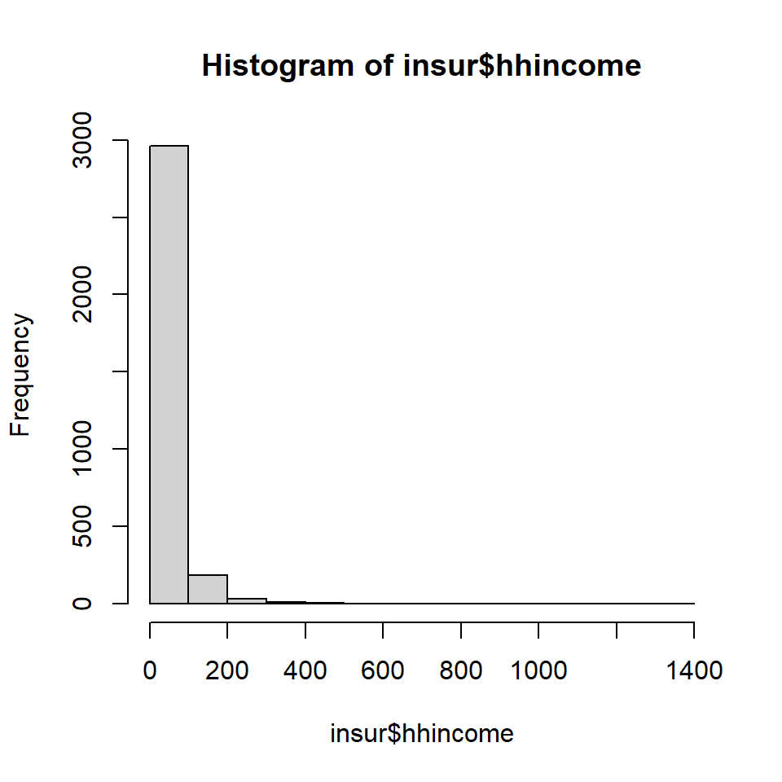

```r
hist(insur$hhincome)
```

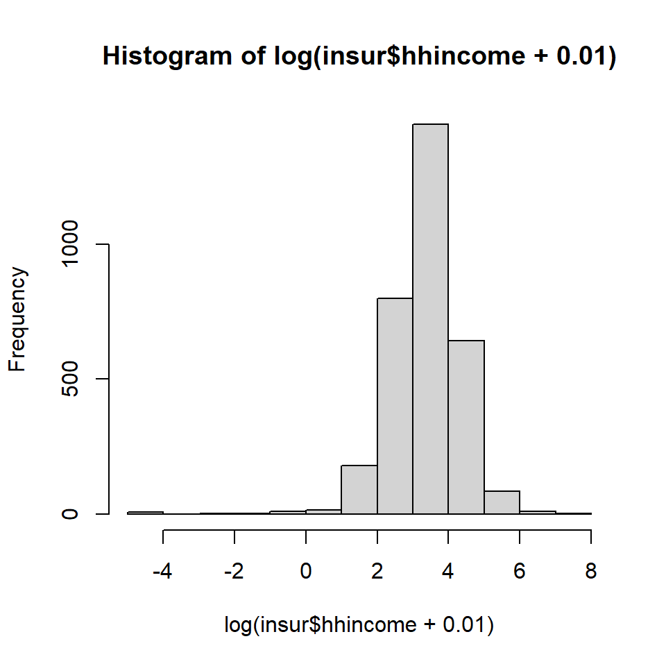

```r
hist(log(insur$hhincome + 0.01))
```

## 1a)

*Aufgrund der Rechtsschiefe des Einkommens entscheiden Sie sich fur eine Logarithmierung. Addieren Sie zur Vermeidung von NAs dabei zur Ursprungsvariable zunachst die Konstante 0,001. Dummyvariablen sollten Sie zunachst zu Faktoren umwandeln.*

```r
summary(insur$hhincome)
```

```
##    Min. 1st Qu.  Median    Mean 3rd Qu.    Max.
##    0.00   17.00   31.10   45.26   52.80 1312.12
```

```r
insur$loghhincome <- insur$hhincome + 0.001
summary(insur$loghhincome)
```

```
##     Min.  1st Qu.   Median     Mean  3rd Qu.     Max.
##    0.001   17.002   31.105   45.265   52.801 1312.125
```

```r
insur$loghhincome <- log(insur$loghhincome)
summary(insur$loghhincome)
```

```
##    Min. 1st Qu.  Median    Mean 3rd Qu.    Max.
##  -6.908   2.833   3.437   3.354   3.967   7.179
```

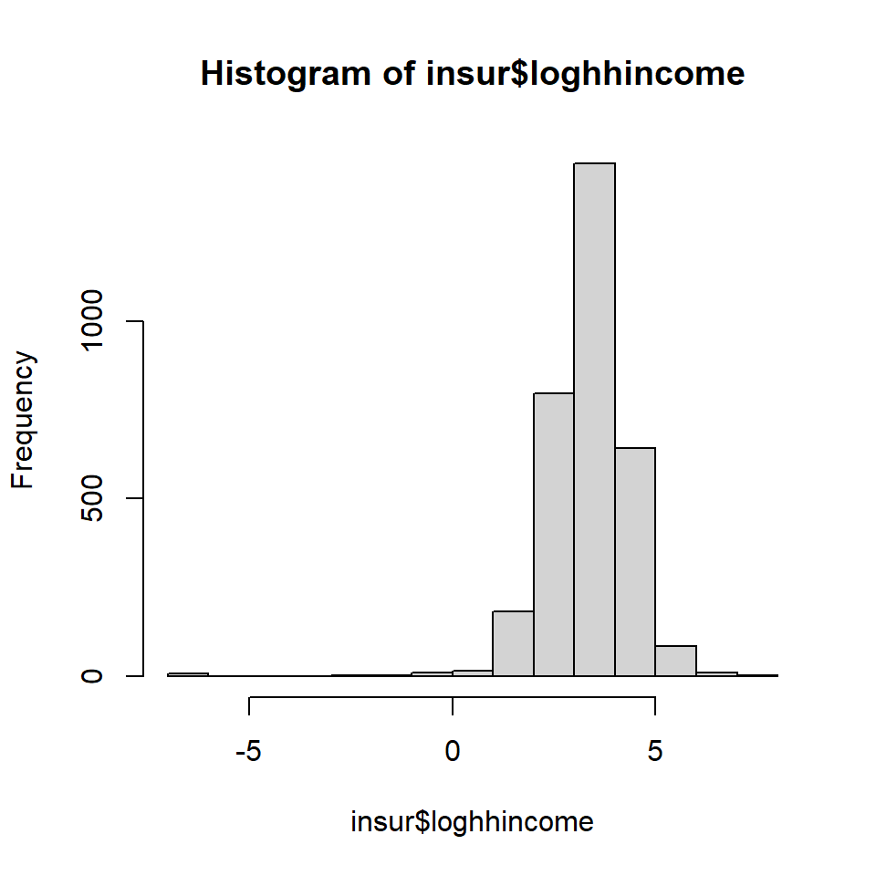

```r
hist(insur$loghhincome)
```

```r
insur$ins <- as.factor(insur$ins)
insur$married <- as.factor(insur$married)
insur$retire <- as.factor(insur$retire)
insur$hstatusg <- as.factor(insur$hstatusg)
insur$hisp <- as.factor(insur$hisp)
str(insur)
```

```
## 'data.frame':    3206 obs. of  27 variables:
##  $ ins        : Factor w/ 2 levels "0","1": 1 1 1 1 1 1 1 1 1 1 ...
##  $ retire     : Factor w/ 2 levels "0","1": 1 1 2 1 1 2 1 1 1 1 ...
##  $ age        : int  62 59 60 62 54 62 59 59 65 58 ...
##  $ hstatusg   : Factor w/ 2 levels "0","1": 1 1 2 1 1 2 1 1 1 1 ...
##  $ hhincome   : num  0 0 0 0 0 0 0 0 0 0.101 ...
##  $ educyear   : int  12 12 13 10 9 12 5 11 14 12 ...
##  $ married    : Factor w/ 2 levels "0","1": 1 1 1 1 1 2 2 1 1 1 ...
##  $ hisp       : Factor w/ 2 levels "0","1": 1 1 1 1 1 1 1 1 1 1 ...
##  $ personid   : int  54963010 21629010 20421010 38784010 55630030 15893020 86263010 51270010 57341010 39703010 ...
##  $ private    : int  0 0 0 0 0 0 0 0 0 0 ...
##  $ eprhi      : int  0 0 0 0 0 0 0 0 0 0 ...
##  $ white      : int  0 1 0 1 1 1 0 1 0 1 ...
##  $ female     : int  1 1 0 1 1 1 0 1 0 1 ...
##  $ excel      : int  0 0 0 0 0 0 0 0 0 0 ...
##  $ vegood     : int  0 0 1 0 0 1 0 0 0 0 ...
##  $ good       : int  0 0 0 0 0 0 0 0 0 0 ...
##  $ fair       : int  1 1 0 1 0 0 0 0 0 0 ...
##  $ poor       : int  0 0 0 0 1 0 1 1 1 1 ...
##  $ chronic    : int  3 1 2 4 6 0 4 2 2 3 ...
##  $ adl        : int  0 3 0 3 0 0 0 2 3 1 ...
##  $ seprhi     : int  0 0 0 0 0 0 0 0 0 0 ...
##  $ sretire    : int  0 0 0 0 0 1 0 0 0 0 ...
##  $ age2       : int  3844 3481 3600 3844 2916 3844 3481 3481 4225 3364 ...
##  $ agefem     : int  62 59 0 62 54 62 0 59 0 58 ...
##  $ agechr     : int  186 59 120 248 324 0 236 118 130 174 ...
##  $ agewhi     : int  0 59 0 62 54 62 0 59 0 58 ...
##  $ loghhincome: num  -6.91 -6.91 -6.91 -6.91 -6.91 ...
```

## 1b)

*Passen Sie zunachst einmal das volle Modell an und nutzen Sie dabei den Logit-Link.*

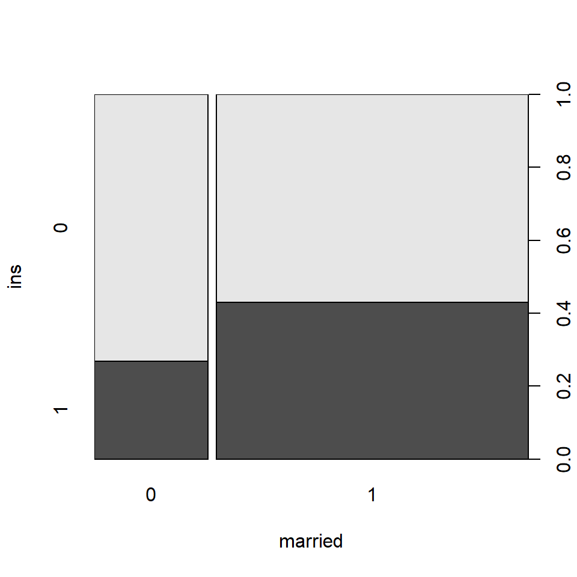

```r
plot(ins ~ married, data = insur)
```

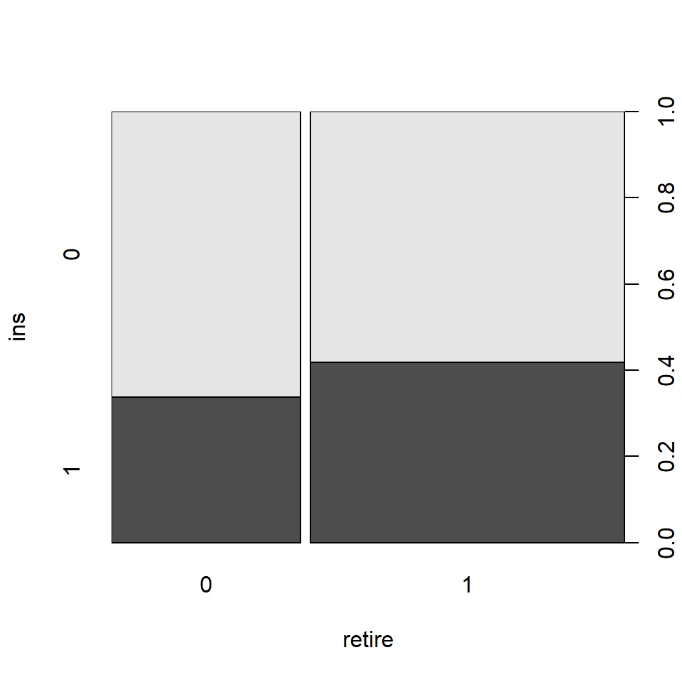

```r
plot(ins ~ retire, data = insur)
```

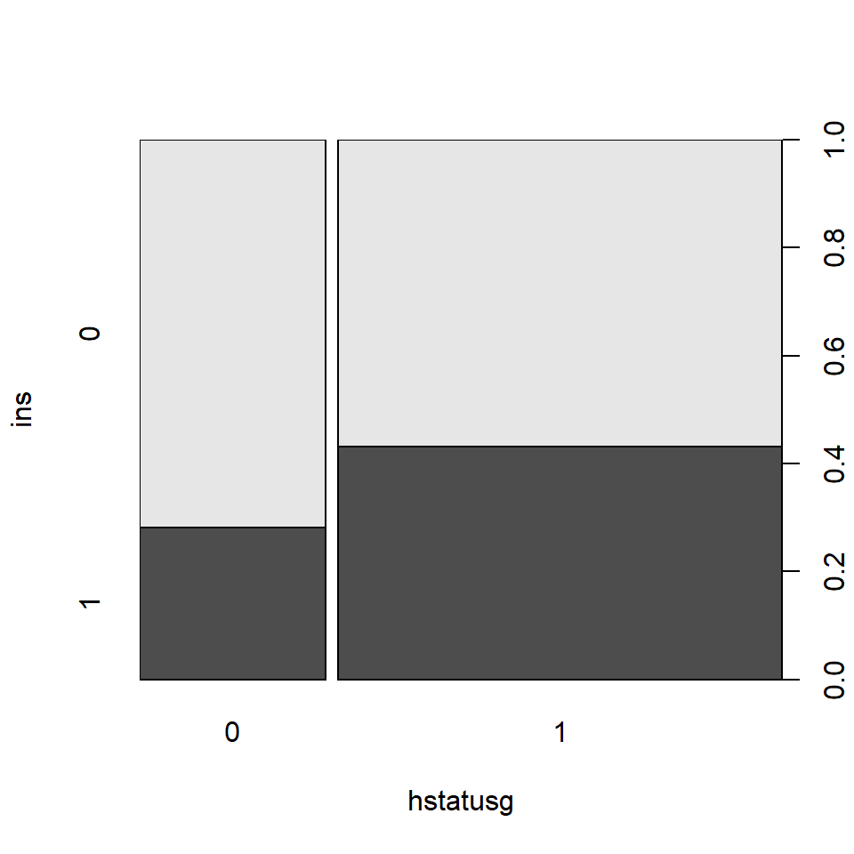

```r
plot(ins ~ hstatusg, data = insur)
```

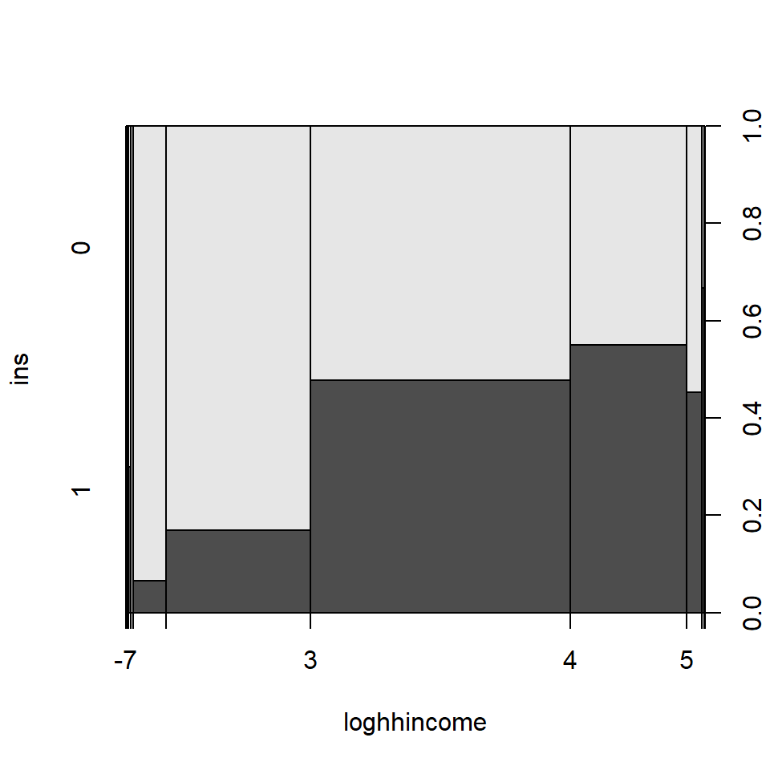

```r
plot(ins ~ loghhincome, data = insur)
```

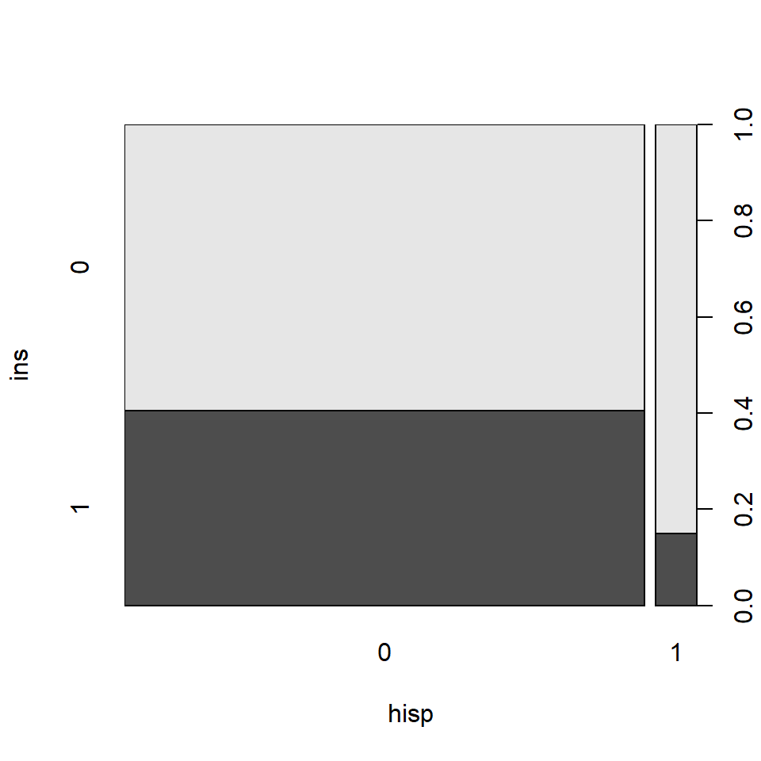

```r
plot(ins ~ hisp, data = insur)
```

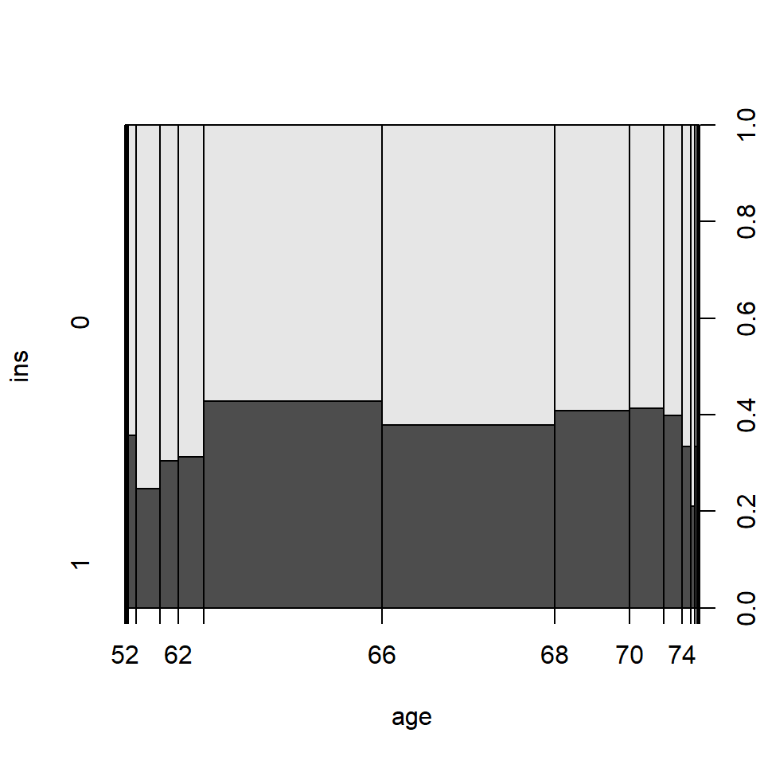

```r
plot(ins ~ age, data = insur)
```

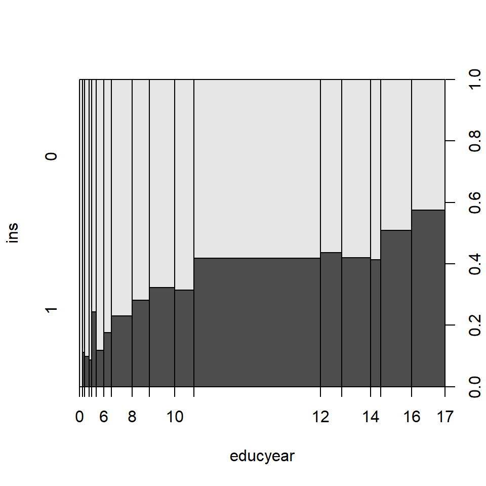

```r
plot(ins ~ educyear, data = insur)
```

```r
logRegFull <- glm(ins ~ married + retire + hstatusg + loghhincome +
                   age + hisp + educyear, family = binomial(link = "logit"), data = insur)
summary(logRegFull)
```

```
##
## Call:
## glm(formula = ins ~ married + retire + hstatusg + loghhincome +
##     age + hisp + educyear, family = binomial(link = "logit"),
##     data = insur)
##
## Deviance Residuals:
##     Min       1Q   Median       3Q      Max
## -2.1376  -0.9812  -0.6233   1.1648   2.7096
##
## Coefficients:
##             Estimate Std. Error z value Pr(>|z|)
## (Intercept) -2.31533    0.76966  -3.008 0.002628 **
## married1     0.16924    0.10244   1.652 0.098495 .
## retire1      0.22516    0.08542   2.636 0.008393 **
## hstatusg1    0.16493    0.09439   1.747 0.080595 .
## loghhincome  0.60333    0.05874  10.272  < 2e-16 ***
## age         -0.02080    0.01156  -1.799 0.071955 .
## hisp1       -0.69572    0.19804  -3.513 0.000443 ***
## educyear     0.06697    0.01487   4.502 6.73e-06 ***
## ---
## Signif. codes:  0 '***' 0.001 '**' 0.01 '*' 0.05 '.' 0.1 ' ' 1
##
## (Dispersion parameter for binomial family taken to be 1)
##
##     Null deviance: 4279.5  on 3205  degrees of freedom
## Residual deviance: 3879.1  on 3198  degrees of freedom
## AIC: 3895.1
##
## Number of Fisher Scoring iterations: 4
```

## 1c)

*Zur Diagnostik schauen Sie sich den binned residual plot an. Dazu verwenden Sie die Funktion binnedplot aus dem arm-Paket und plotten die geﬁtteten Werte auf die Abszisse und die Residuen auf die Ordinate. Wie interpretieren Sie die Graﬁk? Die Funktion binned.resids mit den bereits zum Plotten genutzten Argumenten konnte Ihnen hier helfen.*

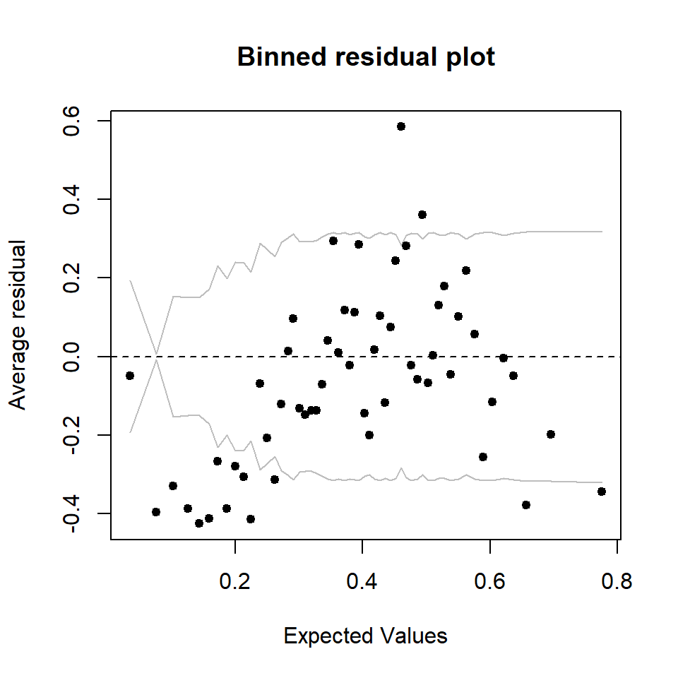

```r
binnedplot(fitted(logRegFull), residuals(logRegFull))
```

```r
br <- binned.resids(fitted(logRegFull), residuals(logRegFull))
str(br)
```

```
## List of 2
##  $ binned : num [1:56, 1:6] 0.0348 0.0756 0.1031 0.1263 0.144 ...
##   ..- attr(*, "dimnames")=List of 2
##   .. ..$ : NULL
##   .. ..$ : chr [1:6] "xbar" "ybar" "n" "x.lo" ...
##  $ xbreaks: NULL
```

```r
head(br$binned)
```

```
##            xbar        ybar  n         x.lo       x.hi         2se
## [1,] 0.03475848 -0.04878213 57 0.0007413623 0.05818533 0.192710645
## [2,] 0.07557390 -0.39567297 57 0.0585931871 0.08993472 0.007156088
## [3,] 0.10312789 -0.33003681 57 0.0902135016 0.11452802 0.153911852
## [4,] 0.12625091 -0.38750107 58 0.1154389123 0.13532428 0.149393430
## [5,] 0.14395744 -0.42486825 57 0.1355577292 0.15241876 0.149788393
## [6,] 0.15897372 -0.41262244 57 0.1528401061 0.16453118 0.170887033
```

```r
mean(abs(br$binned[, "ybar"]) <= br$binned[, "2se"])
```

```
## [1] 0.7321429
```

Die Coverage Rate ist sehr gering. Das spricht fur eine Fehlspezifikation.

## 1d)

*Interpretieren Sie zunachst ganz allgemein die Regressionskoffizienten Ihres Modells. Wie verandert sich c.p. durch eine Heirat die Chance, krankenversichert zu sein? Wie verandert sich c.p. die Chance, wenn eine Person ein weiteres Ausbildungsjahr absolviert hat?*

Die Chance, krankversichert relativ zu nicht krankversichert zu sein, nimmt wenn man verheiratet relativ zu nicht verheiratet ist, und die Absolvierung eines weiteren Ausbildungsjahres zu.

```r
exp(coef(logRegFull))
```

```
## (Intercept)    married1     retire1   hstatusg1 loghhincome         age
##  0.09873372  1.18440784  1.25251899  1.17930509  1.82819651  0.97941183
##       hisp1    educyear
##  0.49871690  1.06926185
```

## 1e)

*Berechnen Sie den durchschnittlichen marginalen Effekt einer Veranderung der Variable retire.*

```r
eff_retire <- fitted(logRegFull)*(1 - fitted(logRegFull))*coef(logRegFull)["retire1"]
ame_retire <- mean(eff_retire)
ame_retire
```

```
## [1] 0.04723126
```

Der durchschnittliche marginale Effekt einer Veranderung der Variable retire ist 0.04723126: Im Durchschnitt erhoht sich die Wahrscheinlichkeit, versichert zu sein um 0.0472, wenn die Person zum Rentner wird.

## 1f)

*Passen Sie ein Modell ohne die Variablen married, retire und hisp an. Berechnen Sie sodann anhand dieses Modells den marginalen Effekt im Mittelwert bezuglich der Variable educyear.*

```r
logRegRest <- glm(ins ~ hstatusg + loghhincome +
                   age + educyear, family = binomial(link = "logit"), data = insur)
summary(logRegRest)
```

```
##
## Call:
## glm(formula = ins ~ hstatusg + loghhincome + age + educyear,
##     family = binomial(link = "logit"), data = insur)
##
## Deviance Residuals:
##     Min       1Q   Median       3Q      Max
## -2.1675  -0.9654  -0.6411   1.1764   2.8231
##
## Coefficients:
##             Estimate Std. Error z value Pr(>|z|)
## (Intercept) -3.05659    0.74271  -4.115 3.86e-05 ***
## hstatusg1    0.16618    0.09390   1.770   0.0768 .
## loghhincome  0.65222    0.05321  12.257  < 2e-16 ***
## age         -0.01066    0.01098  -0.971   0.3317
## educyear     0.07754    0.01423   5.451 5.01e-08 ***
## ---
## Signif. codes:  0 '***' 0.001 '**' 0.01 '*' 0.05 '.' 0.1 ' ' 1
##
## (Dispersion parameter for binomial family taken to be 1)
##
##     Null deviance: 4279.5  on 3205  degrees of freedom
## Residual deviance: 3903.6  on 3201  degrees of freedom
## AIC: 3913.6
##
## Number of Fisher Scoring iterations: 4
```

```r
X <- model.matrix(logRegRest)
X_bar <- colMeans(X)
X_bar0 <- X_bar
X_bar0["hstatusg1"] <- 0
eta_0 <- X_bar0 %*% coef(logRegRest)

prob_0 <- exp(eta_0)/(1 + exp(eta_0))
prob_0
```

```
##           [,1]
## [1,] 0.3408745
```

```r
binomial()$linkinv(eta_0)
```

```
##           [,1]
## [1,] 0.3408745
```

```r
mem_0 <- prob_0 * (1 - prob_0) * coef(logRegRest)["educyear"]
mem_0
```

```
##            [,1]
## [1,] 0.01742266
```

```r
X_bar1 <- X_bar
X_bar1["hstatusg1"] <- 1
eta_1 <- X_bar1 %*% coef(logRegRest)

prob_1 <- exp(eta_1)/(1 + exp(eta_1))

mem_1 <- prob_1 * (1 - prob_1) * coef(logRegRest)["educyear"]
mem_1
```

```
##            [,1]
## [1,] 0.01825336
```

MEM bei einer ungesunden Person: mit einem weiteren Bidlungsjahr steigt die Wahrscheinlichkeit, versichert zu sein um 1,7%.

MEM bei einer gesunden Person: mit einem weiteren Bidlungsjahr steigt die Wahrscheinlichkeit, versichert zu sein um 1,8%.

## 1g)

*Schauen Sie sich die Effektplots fur die Variable educyear im Modell aus Teilaufgabe b) an. Hinweis: Nutzen Sie die Funktion allEffects aus dem effects-Paket.*

```r
logit_eff <- allEffects(logRegFull)
names(logit_eff)
```

```
## [1] "married"     "retire"      "hstatusg"    "loghhincome" "age"
## [6] "hisp"        "educyear"
```

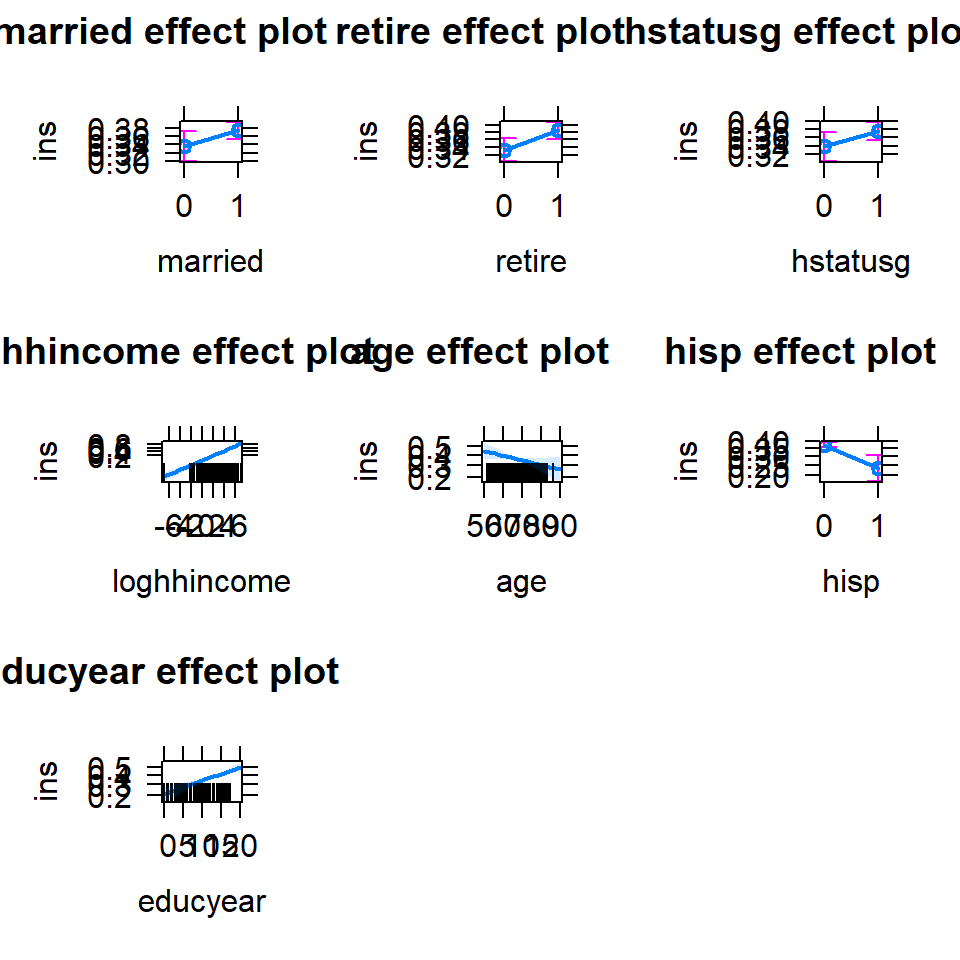

```r
plot(logit_eff)
```

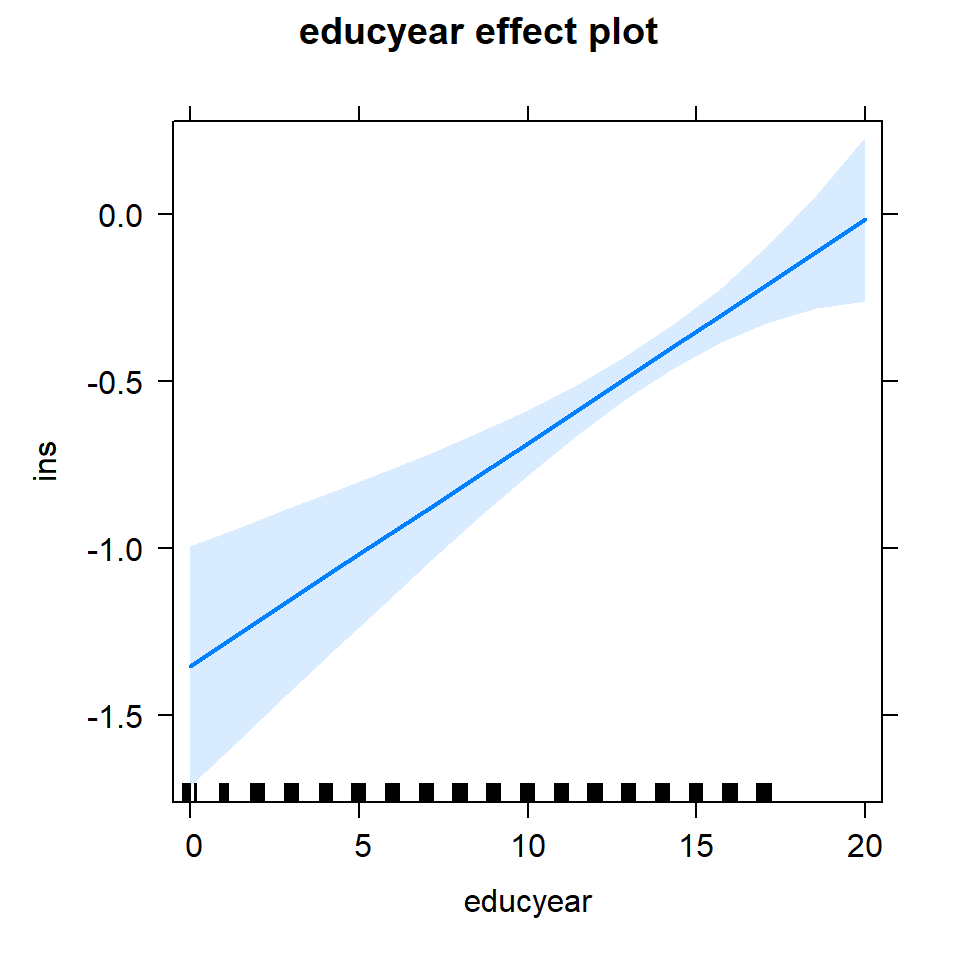

```r
plot(logit_eff[[7]], type = "link")
```

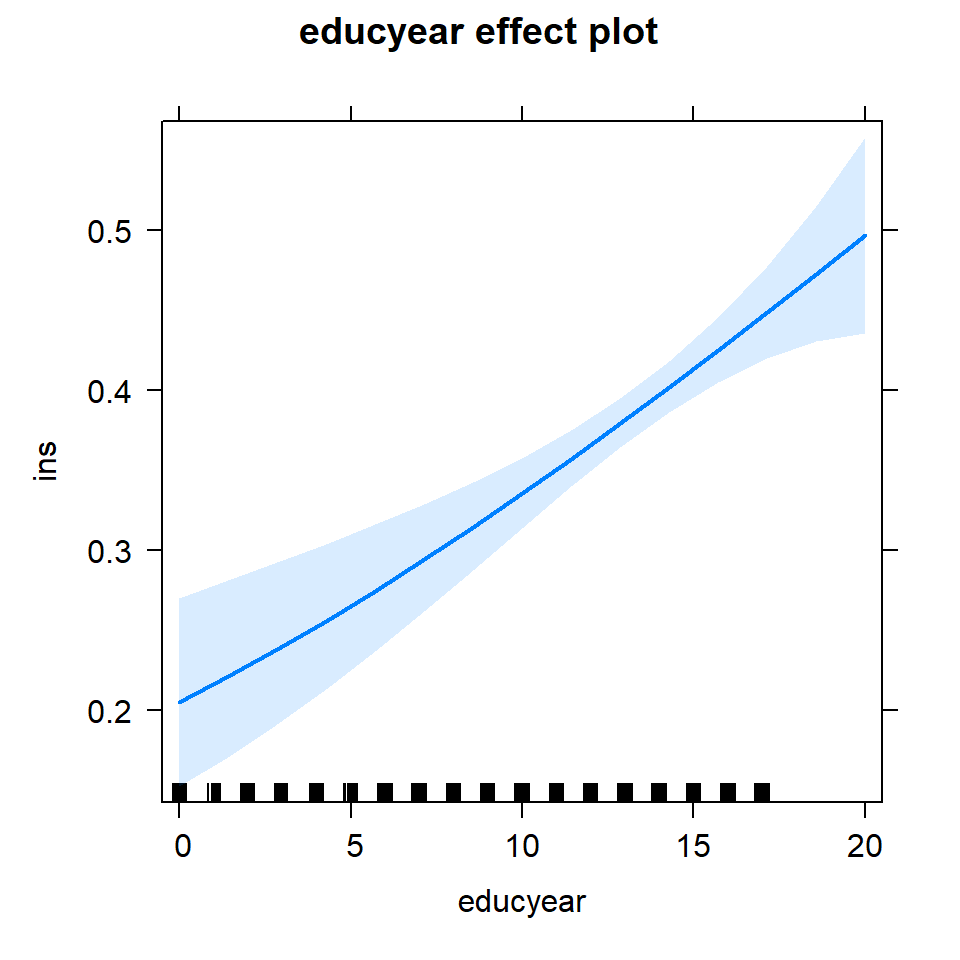

```r
plot(logit_eff[[7]], type = "response")
```

## 1h)

*Wie hoch ist der Anteil korrekt vorhergesagter Werte im Modell aus Teilaufgabe b)? Als Schwellenwert setzen Sie 0,5 an.*

```r
tab <- prop.table(table(Wahr = insur$ins, Prog = round(fitted(logRegFull))))
tab
```

```
##     Prog
## Wahr         0         1
##    0 0.4918902 0.1210231
##    1 0.2414223 0.1456644
```

```r
sum(diag(tab))
```

```
## [1] 0.6375546
```

Beim Schwellenwert von 0.5 ist der Anteil der korrekt vorhergesagten Werte betragt 63.76%.

## 1i)

*Berechnen Sie fur das Modell aus Teilaufgabe b) das Pseudo-R2.*

```r
logRegNull <- glm(ins ~ 1, family = binomial(link = "logit"), data = insur)

PseudoR2 <- 1 - logLik(logRegFull)/logLik(logRegNull)
PseudoR2
```

```
## 'log Lik.' 0.09356729 (df=8)
```

```r
1 - logRegFull$deviance/logRegFull$null.deviance
```

```
## [1] 0.09356729
```

Das Pseudo-R2 fur das Modell aus Teilaufgabe b) betragt 0.0936

## 1j)

*Fuhren Sie fur das Modell aus Teilaufgabe b) einen Test auf Fehlspeziﬁkation durch. Hinweis: Nutzen Sie die Funktion lrtest aus dem lmtest-Paket.*

```r
lrtest(logRegNull, logRegFull)
```

| #Df | LogLik | Df | Chisq | Pr(>Chisq) |
| --- | --- | --- | --- | --- |
| 1 | -2139.771 | NA | NA | NA |
| 8 | -1939.559 | 7 | 400.4252 | 0 |

```r
lrtest(logRegFull, . ~ . + I(predict(logRegFull, type = "link")^2))
```

| #Df | LogLik | Df | Chisq | Pr(>Chisq) |
| --- | --- | --- | --- | --- |
| 8 | -1939.559 | NA | NA | NA |
| 9 | -1914.466 | 1 | 50.18542 | 0 |

Da das erweiterte Modell mit $\widehat{η^2_i}$ eine signifikant kleinere Signifikanz als das Modell ohne $\widehat{η^2_i}$, ist das Modell inkorrekt spezifiziert. Wie konnen davon ausgehen, dass quadrierter linearer Pradiktor einen signifikanten Erklarungsgehalt hatte.

## 1k)

*Fuhren Sie eine Variablenselektion mit der schrittweisen Selektion durch. Gehen Sie vom Modell aus Teilaufgabe b) aus und geben Sie dieses Modell mit samtlichen Interaktionstermen zweiter Ordnung als Maximalmodellan (uber Nutzung von ^2 in Formel). Nutzen Sie dabei das Paket MASS.*

```r
step_mod <- stepAIC(logRegFull, scope = list(upper = ~ .^2), direction = "both")
```

```
## Start:  AIC=3895.12
## ins ~ married + retire + hstatusg + loghhincome + age + hisp +
##     educyear
##
##                        Df Deviance    AIC
## + loghhincome:educyear  1   3846.9 3864.9
## + hstatusg:loghhincome  1   3852.6 3870.6
## + loghhincome:hisp      1   3863.6 3881.6
## + married:educyear      1   3865.1 3883.1
## + married:hstatusg      1   3868.9 3886.9
## + loghhincome:age       1   3873.8 3891.8
## + married:loghhincome   1   3875.8 3893.8
## + age:hisp              1   3876.5 3894.5
## + hstatusg:hisp         1   3876.9 3894.9
## + retire:educyear       1   3877.0 3895.0
## + hstatusg:educyear     1   3877.1 3895.1
## <none>                      3879.1 3895.1
## + hisp:educyear         1   3877.8 3895.8
## - married               1   3881.9 3895.9
## + married:age           1   3878.1 3896.1
## - hstatusg              1   3882.2 3896.2
## - age                   1   3882.4 3896.4
## + retire:hstatusg       1   3878.9 3896.9
## + married:retire        1   3879.0 3897.0
## + retire:loghhincome    1   3879.0 3897.0
## + age:educyear          1   3879.0 3897.0
## + retire:age            1   3879.1 3897.1
## + retire:hisp           1   3879.1 3897.1
## + married:hisp          1   3879.1 3897.1
## + hstatusg:age          1   3879.1 3897.1
## - retire                1   3886.1 3900.1
## - hisp                  1   3892.8 3906.8
## - educyear              1   3899.7 3913.7
## - loghhincome           1   4000.7 4014.7
##
## Step:  AIC=3864.92
## ins ~ married + retire + hstatusg + loghhincome + age + hisp +
##     educyear + loghhincome:educyear
##
##                        Df Deviance    AIC
```

[output cut: 137 more lines]

```
## + age:educyear          1   3816.2 3844.2
## + hstatusg:educyear     1   3816.3 3844.3
## - age:hisp              1   3820.4 3844.4
## + retire:hisp           1   3816.5 3844.5
## + retire:age            1   3816.7 3844.7
## + married:age           1   3816.8 3844.8
## - married:educyear      1   3820.8 3844.8
## + married:loghhincome   1   3816.8 3844.8
## + hstatusg:age          1   3816.9 3844.9
## + retire:hstatusg       1   3816.9 3844.9
## + hisp:educyear         1   3816.9 3844.9
## - retire                1   3822.0 3846.0
## - loghhincome:hisp      1   3825.7 3849.7
## - loghhincome:educyear  1   3826.0 3850.0
## - hstatusg:loghhincome  1   3830.8 3854.8
```

```r
summary(step_mod)
```

```
##
## Call:
## glm(formula = ins ~ married + retire + hstatusg + loghhincome +
##     age + hisp + educyear + loghhincome:educyear + hstatusg:loghhincome +
##     loghhincome:hisp + married:educyear + age:hisp, family = binomial(link = "logit"),
##     data = insur)
##
## Deviance Residuals:
##     Min       1Q   Median       3Q      Max
## -2.1576  -1.0312  -0.5282   1.1458   2.7602
##
## Coefficients:
##                       Estimate Std. Error z value Pr(>|z|)
## (Intercept)           -6.86123    1.14998  -5.966 2.43e-09 ***
## married1               1.09306    0.49975   2.187 0.028728 *
## retire1                0.19363    0.08593   2.253 0.024245 *
## hstatusg1              1.68388    0.43978   3.829 0.000129 ***
## loghhincome            1.61543    0.24757   6.525 6.79e-11 ***
## age                   -0.01476    0.01202  -1.228 0.219449
## hisp1                  2.23278    3.34802   0.667 0.504839
## educyear               0.32319    0.06632   4.873 1.10e-06 ***
## loghhincome:educyear  -0.05541    0.01862  -2.976 0.002925 **
## hstatusg1:loghhincome -0.45768    0.12631  -3.623 0.000291 ***
## loghhincome:hisp1      0.99047    0.36383   2.722 0.006482 **
## married1:educyear     -0.07557    0.03865  -1.955 0.050538 .
## age:hisp1             -0.09171    0.05001  -1.834 0.066673 .
## ---
## Signif. codes:  0 '***' 0.001 '**' 0.01 '*' 0.05 '.' 0.1 ' ' 1
##
## (Dispersion parameter for binomial family taken to be 1)
##
##     Null deviance: 4279.5  on 3205  degrees of freedom
## Residual deviance: 3816.9  on 3193  degrees of freedom
## AIC: 3842.9
##
## Number of Fisher Scoring iterations: 6
```

# Aufgabe 2: Probit Modelle

## 2a)

*Passen Sie das gleiche Modell wie in Aufgabe 1 b) an, verwenden Sie diesmal jedoch die Probit-Linkfunktion.*

```r
probRegFull <- glm(ins ~ married + retire + hstatusg + loghhincome +
                   age + hisp + educyear, family = binomial(link = "probit"), data = insur)
summary(probRegFull)
```

```
##
## Call:
## glm(formula = ins ~ married + retire + hstatusg + loghhincome +
##     age + hisp + educyear, family = binomial(link = "probit"),
##     data = insur)
##
## Deviance Residuals:
##     Min       1Q   Median       3Q      Max
## -2.1528  -0.9813  -0.6174   1.1695   2.8918
##
## Coefficients:
##              Estimate Std. Error z value Pr(>|z|)
## (Intercept) -1.395542   0.464774  -3.003 0.002677 **
## married1     0.111064   0.061690   1.800 0.071806 .
## retire1      0.133419   0.051814   2.575 0.010025 *
## hstatusg1    0.111481   0.056969   1.957 0.050362 .
## loghhincome  0.355738   0.034929  10.185  < 2e-16 ***
## age         -0.012846   0.006991  -1.837 0.066155 .
## hisp1       -0.419304   0.112167  -3.738 0.000185 ***
## educyear     0.042594   0.008926   4.772 1.83e-06 ***
## ---
## Signif. codes:  0 '***' 0.001 '**' 0.01 '*' 0.05 '.' 0.1 ' ' 1
##
## (Dispersion parameter for binomial family taken to be 1)
##
##     Null deviance: 4279.5  on 3205  degrees of freedom
## Residual deviance: 3876.0  on 3198  degrees of freedom
## AIC: 3892
##
## Number of Fisher Scoring iterations: 5
```

## 2b)

*Vergleichen Sie die geschatzten Wahrscheinlichkeiten aus dem Logit- und Probit-Modell.*

```r
summary(logRegFull)
```

```
##
## Call:
## glm(formula = ins ~ married + retire + hstatusg + loghhincome +
##     age + hisp + educyear, family = binomial(link = "logit"),
##     data = insur)
##
## Deviance Residuals:
##     Min       1Q   Median       3Q      Max
## -2.1376  -0.9812  -0.6233   1.1648   2.7096
##
## Coefficients:
##             Estimate Std. Error z value Pr(>|z|)
## (Intercept) -2.31533    0.76966  -3.008 0.002628 **
## married1     0.16924    0.10244   1.652 0.098495 .
## retire1      0.22516    0.08542   2.636 0.008393 **
## hstatusg1    0.16493    0.09439   1.747 0.080595 .
## loghhincome  0.60333    0.05874  10.272  < 2e-16 ***
## age         -0.02080    0.01156  -1.799 0.071955 .
## hisp1       -0.69572    0.19804  -3.513 0.000443 ***
## educyear     0.06697    0.01487   4.502 6.73e-06 ***
## ---
## Signif. codes:  0 '***' 0.001 '**' 0.01 '*' 0.05 '.' 0.1 ' ' 1
##
## (Dispersion parameter for binomial family taken to be 1)
##
##     Null deviance: 4279.5  on 3205  degrees of freedom
## Residual deviance: 3879.1  on 3198  degrees of freedom
## AIC: 3895.1
##
## Number of Fisher Scoring iterations: 4
```

```r
summary(probRegFull)
```

```
##
## Call:
## glm(formula = ins ~ married + retire + hstatusg + loghhincome +
##     age + hisp + educyear, family = binomial(link = "probit"),
##     data = insur)
##
## Deviance Residuals:
##     Min       1Q   Median       3Q      Max
## -2.1528  -0.9813  -0.6174   1.1695   2.8918
##
## Coefficients:
##              Estimate Std. Error z value Pr(>|z|)
## (Intercept) -1.395542   0.464774  -3.003 0.002677 **
## married1     0.111064   0.061690   1.800 0.071806 .
## retire1      0.133419   0.051814   2.575 0.010025 *
## hstatusg1    0.111481   0.056969   1.957 0.050362 .
## loghhincome  0.355738   0.034929  10.185  < 2e-16 ***
## age         -0.012846   0.006991  -1.837 0.066155 .
## hisp1       -0.419304   0.112167  -3.738 0.000185 ***
## educyear     0.042594   0.008926   4.772 1.83e-06 ***
## ---
## Signif. codes:  0 '***' 0.001 '**' 0.01 '*' 0.05 '.' 0.1 ' ' 1
##
## (Dispersion parameter for binomial family taken to be 1)
##
##     Null deviance: 4279.5  on 3205  degrees of freedom
## Residual deviance: 3876.0  on 3198  degrees of freedom
## AIC: 3892
##
## Number of Fisher Scoring iterations: 5
```

## 2c)

*Was konnen Sie uber die $\widehat{β_s}$ der beiden Modelle sagen?*

Die $\widehat{β_s}$ der beiden Modelle unterscheiden sich, haben jedoch die gleichen Vorzeichen.

## 2d)

*Berechnen Sie den Anteil korrekt vorhergesagter Werte fur das Probit-Modell.*

```r
marg_table_insr_prob <- prop.table(table(Obs = insur$ins, Pred = round(fitted(probRegFull))))
marg_table_insr_prob
```

```
##    Pred
## Obs         0         1
##   0 0.4956332 0.1172801
##   1 0.2439177 0.1431691
```

```r
marg_table_insr_prob[1, 1] + marg_table_insr_prob[2, 2]
```

```
## [1] 0.6388022
```

Der Anteil korrekt vorhergesagter Werte fur das Probit-Modell betragt 63.88%.

## 2e)

*Berechnen Sie den durchschnittlichen marginalen Effekt einer Veranderung der Variable retire im Probit-Modell und vergleichen Sie das Ergebnis mit Aufgabe 1 e). Beachten Sie, dass Sie fur diese Berechnung nichteinfach auf die entsprechende Formel des Logit-Modells zuruckgreifen konnen.*

```r
summary(margins(logRegFull, type = "response"))
```

| factor | AME | SE | z | p | lower | upper |
| --- | --- | --- | --- | --- | --- | --- |
| age | -0.0043639 | 0.0024207 | -1.802764 | 0.0714253 | -0.0091083 | 0.0003805 |
| educyear | 0.0140480 | 0.0030848 | 4.553946 | 0.0000053 | 0.0080019 | 0.0200941 |
| hisp1 | -0.1366013 | 0.0352346 | -3.876907 | 0.0001058 | -0.2056599 | -0.0675427 |
| hstatusg1 | 0.0345656 | 0.0197308 | 1.751854 | 0.0797989 | -0.0041062 | 0.0732373 |
| loghhincome | 0.1265609 | 0.0115661 | 10.942429 | 0.0000000 | 0.1038918 | 0.1492300 |
| married1 | 0.0354623 | 0.0213999 | 1.657125 | 0.0974943 | -0.0064807 | 0.0774052 |
| retire1 | 0.0471005 | 0.0177624 | 2.651699 | 0.0080088 | 0.0122869 | 0.0819141 |

```r
summary(margins(probRegFull, type = "response"))
```

| factor | AME | SE | z | p | lower | upper |
| --- | --- | --- | --- | --- | --- | --- |
| age | -0.0044210 | 0.0024025 | -1.840206 | 0.0657380 | -0.0091298 | 0.0002877 |
| educyear | 0.0146594 | 0.0030407 | 4.821140 | 0.0000014 | 0.0086999 | 0.0206190 |
| hisp1 | -0.1364936 | 0.0336106 | -4.061031 | 0.0000489 | -0.2023691 | -0.0706181 |
| hstatusg1 | 0.0383473 | 0.0195516 | 1.961339 | 0.0498395 | 0.0000269 | 0.0766676 |
| loghhincome | 0.1224323 | 0.0114431 | 10.699261 | 0.0000000 | 0.1000043 | 0.1448603 |
| married1 | 0.0381877 | 0.0211541 | 1.805213 | 0.0710413 | -0.0032736 | 0.0796491 |
| retire1 | 0.0458252 | 0.0177175 | 2.586435 | 0.0096975 | 0.0110995 | 0.0805509 |

Der durchschnittliche marginale Effekt einer Veranderung der Variable retire im Probit-Modell betragt 0.0458, wahrend der durchschnittliche marginale Effekt einer Veranderung der Variable retire im Logit-Modell ist 0.0471.